# ZAP (2026) Feedback Sequel

Adrian Martin, Rochester NY

## ZAP Feedback

I am writing this page as feedback to the Rochester City Planning Commission on the Zoning Alignment Project release of 2026. Feedback for the July 13th meeting is due June 18th, 4PM. This will be emailed to the commission, but also posted on github for public access and reproducibility. This is my second round of feedback on the 2026 draft; the first feedback is available [here](https://a517dogg.github.io/ZAP/index.html).

This piece will look more at non-conformities, using both the class usage description as well as lot coverage to compare ZAP’s stated goal of reducing nonconformities with its actual effect (as best as I can model). TDLR: the city should relax lot coverage requirements in MDR zones.

### Non-compliance

[interactive chart not shown]

The above map shows LDR zones in the proposed 2026 ZAP plan, and highlights parcels that are non-conforming based on the parcel description.

I label a parcel as non-conforming in LDR:

- by class description, if it is something other than a single family house, residential vacant land, an aged home, or a detached row building (likely a townhouse which is allowed in LDR, a very welcome change from the 2023 proposal),
- by lot coverage, if the total lot coverage of buildings on the parcel is over 50% of the area of the parcel.

This is an *undercount* because it only shows parcels that are non-conforming because of their land use class or lot coverage, but there are also parcels that are non-conforming because of size, setbacks, height, frontage, etc.

What’s the cause of most of the non-conforming labels in the above map?

| conforming_ZAP | Zoning_2026 | n | Percent_of_zone |
| --- | --- | --- | --- |
| Fails lot coverage | LDR | 385 | 0.9434887 |
| Fails both class and lot coverage | LDR | 493 | 1.2081557 |
| Unknown | LDR | 2023 | 4.9576043 |
| Fails class | LDR | 5913 | 14.4905161 |
| Yes | LDR | 31992 | 78.4002353 |
| Fails lot coverage | MDR | 790 | 5.1129377 |
| Unknown | MDR | 3547 | 22.9564429 |
| Yes | MDR | 11114 | 71.9306194 |

Here’s a table of class usages that result in nonconforming labels:

| Description | count | percent |
| --- | --- | --- |
| 2 Family Residential | 5644 | 74.449281 |
| 1 Family Residential | 834 | 11.001187 |
| 3 Family Residential | 329 | 4.339797 |
| Apartment | 265 | 3.495581 |
| Other | 242 | 3.192191 |
| Multiple Residential | 104 | 1.371851 |
| Residential with Improvements | 85 | 1.121224 |
| Religious | 78 | 1.028888 |

| duplex | conforming_cov | n |
| --- | --- | --- |
| FALSE | FALSE | 1085 |
| FALSE | TRUE | 41061 |
| TRUE | FALSE | 625 |
| TRUE | TRUE | 8410 |
| NA | TRUE | 12 |

Duplexes in LDR are also more likely (7% compared to 2.5%) to be nonconforming due to lot coverage. Duplexes should be encouraged in LDR, but let’s make sure we contine to protect them by preserving duplex rights from abandonment/destruction.

Likely due to additional setback requirements (which I didn’t have time to model), a large majority of properties in LDR and MDR are in compliance with lot coverage requirements:

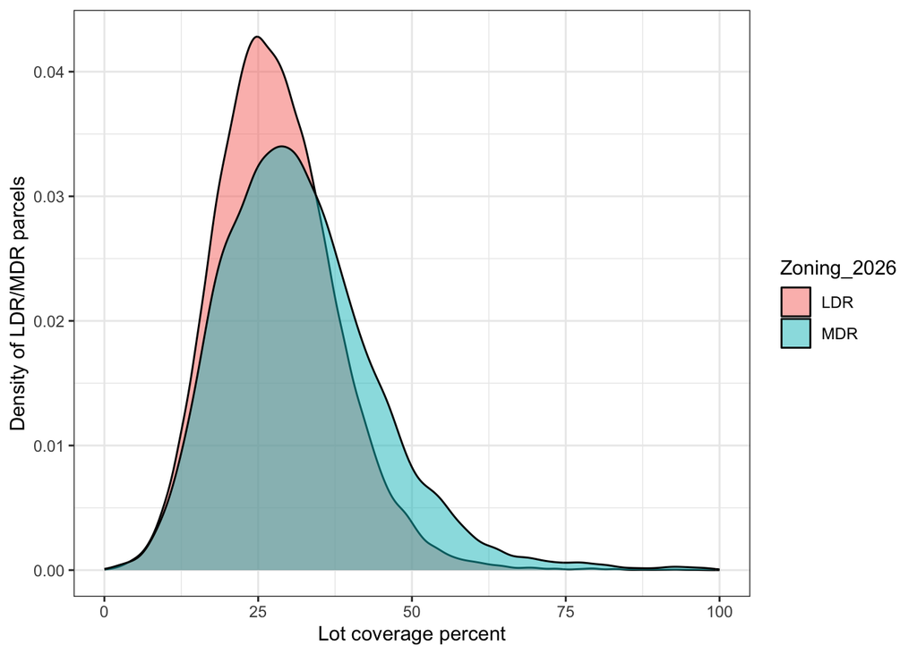

One of the stated purposes of this zoning code is to gradually eliminate non-conforming uses and reuse or eliminate non-conforming structures. Thousands of our neighbors (including me!) live in non-conforming residential structures because the code is too strict.

## Conclusion

### Data & Reproducibility

All data used in this analysis is available either via the city’s open data portal or the city’s FOIL website. All tools in this analysis are open source. All code is posted to [github](https://github.com/a517dogg/ZAP). Anyone is free to reproduce and hopefully improve this analysis.

2026 ZAP zoning file released via FOIL: [download here](https://rochesterny.justfoia.com/Attachments/Download/d1d0f25a-662a-4745-963e-d2fe7797b560)

2023 ZAP zoning file also released via FOIL: [download here](https://github.com/a517dogg/ZAP/blob/main/DRAFT_ZAP_Districts_Sept2023.zip)

[^1]: “More tall buildings with residents offers more customers for local businesses. The few tall apartment buildings along Park Ave contribute to the success of businesses along that corridor.” page 16